# SI 370: Homework 3: Speed Dating

The background material and motivation for this assignment is based on work by Anna Shen on a dataset provided by Anna Montoya from the Kaggle Team. In this assignment you will answer 6 questions.

### About the data (quoted from Anna Shen):

- Data was gathered from 552 participants in experimental speed dating events from 2002-2004.
- During the events, the attendees would have a four minute "first date" with every other participant of the opposite sex.
- At the end of their four minutes, participants were asked if they would like to see their date again. They were also asked to rate their date on six attributes:
  - Attractiveness
  - Sincerity
  - Intelligence
  - Fun
  - Ambition
  - Shared Interests.
- The dataset also includes questionnaire data gathered from participants at different points in the process. These fields include:
  - demographics
  - dating habits
  - self-perception across key attributes
  - beliefs on what others find valuable in a mate
  - lifestyle information

See the speed-dating-data-key.doc for data dictionary and question key.

```python
import warnings
warnings.filterwarnings('ignore')
```

```python
import pandas as pd
import seaborn as sns
import numpy as np
import matplotlib.pyplot as plt
```

```python
pd.options.display.max_rows = 1000 #handy for showing truncated results
```

```python
dating = pd.read_csv('data/Speed Dating Data.csv',encoding='ISO-8859-1')
```

```python
dating.head()
```

|  | iid | id | gender | idg | condtn | wave | round | position | positin1 | order | ... | attr3_3 | sinc3_3 | intel3_3 | fun3_3 | amb3_3 | attr5_3 | sinc5_3 | intel5_3 | fun5_3 | amb5_3 |
| --- | --- | --- | --- | --- | --- | --- | --- | --- | --- | --- | --- | --- | --- | --- | --- | --- | --- | --- | --- | --- | --- |
| 0 | 1 | 1.0 | 0 | 1 | 1 | 1 | 10 | 7 | NaN | 4 | ... | 5.0 | 7.0 | 7.0 | 7.0 | 7.0 | NaN | NaN | NaN | NaN | NaN |
| 1 | 1 | 1.0 | 0 | 1 | 1 | 1 | 10 | 7 | NaN | 3 | ... | 5.0 | 7.0 | 7.0 | 7.0 | 7.0 | NaN | NaN | NaN | NaN | NaN |
| 2 | 1 | 1.0 | 0 | 1 | 1 | 1 | 10 | 7 | NaN | 10 | ... | 5.0 | 7.0 | 7.0 | 7.0 | 7.0 | NaN | NaN | NaN | NaN | NaN |
| 3 | 1 | 1.0 | 0 | 1 | 1 | 1 | 10 | 7 | NaN | 5 | ... | 5.0 | 7.0 | 7.0 | 7.0 | 7.0 | NaN | NaN | NaN | NaN | NaN |
| 4 | 1 | 1.0 | 0 | 1 | 1 | 1 | 10 | 7 | NaN | 7 | ... | 5.0 | 7.0 | 7.0 | 7.0 | 7.0 | NaN | NaN | NaN | NaN | NaN |

5 rows × 195 columns

```python
# dating.iloc[0]
```

Let's drop a bunch of columns so we're left with only the relevant ones. You might choose to incorporate additional columns to help you answer the questions but the following reduction yields a dataset that will allow you to adequately answer the questions below.

```python
# narrowing dataset
dating_1 = dating.iloc[:, 11:28]
dating_2 = dating.iloc[:, 30:35]
dating_3 = dating.iloc[:, 39:43]
dating_4 = dating.iloc[:, 45:67]
dating_5 = dating.iloc[:, 69:74]
dating_6 = dating.iloc[:, 87:91]
dating_7 = dating.iloc[:, 97:102]
dating_8 = dating.iloc[:, 104:107]

dating_narrowed = pd.concat([dating.iloc[:, 0],dating.iloc[:, 2],dating.iloc[:, 9],dating_1,dating_2,dating_3,dating_4,dating_5,
                  dating_6,dating_7,dating_8], axis=1)
```

### Q1: Visualize the distribution of the ages of the participants and provide summary statistics of that distribution (5 points)

```
count    8283.000000
mean       26.358928
std         3.566763
min        18.000000
25%        24.000000
50%        26.000000
75%        28.000000
max        55.000000
Name: age, dtype: float64
```

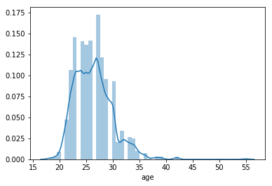

```python
d = dating_2['age'].dropna()
sns.distplot(d)
d.describe()
```

Here, I first must look at the participant age, and drop all null values from the dataframe. Then, using seaborn's distplot module I create a distribution plot of age. Finally, I output summary statistics using pandas describe() module.

## Q2: What proportion of speed daters found a match? (5 points)

Using crosstab, please provide a DataFrame that shows that shows the numer of people that did and did not find a match. In addition to the counts, include in the same DataFrame the proportions that those counts reflect.

```python
dating_narrowed['match'] = dating_narrowed['match'].map({1:'yes', 0:'no'})
ct = pd.crosstab(dating_narrowed.match, columns="count").reset_index()
ct['prop'] = round(ct['count']/ct['count'].sum(), 3)
ct
```

| col_0 | match | count | prop |
| --- | --- | --- | --- |
| 0 | no | 6998 | 0.835 |
| 1 | yes | 1380 | 0.165 |

First I created a crosstab using the values of "match" and a count column, then added a proportion column evaluating the counts/total

### Q3: Visualize the correlations between the variables in the dataset and comment on at least 3 interesting correlations. (5 points)

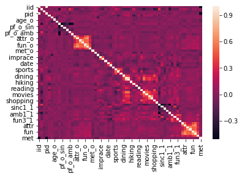

```python
# sns.pairplot(dating_narrowed.corr())
sns.heatmap(dating_narrowed.corr())
```

```python
d_corr = dating_narrowed.corr().abs()
unstack_d = d_corr.unstack()
unstack_d.sort_values(kind="quicksort", ascending=False).head(100)
```

```
met       met         1.000000
yoga      yoga        1.000000
dining    dining      1.000000
museums   museums     1.000000
art       art         1.000000
hiking    hiking      1.000000
gaming    gaming      1.000000
clubbing  clubbing    1.000000
reading   reading     1.000000
tv        tv          1.000000
theater   theater     1.000000
movies    movies      1.000000
concerts  concerts    1.000000
music     music       1.000000
shopping  shopping    1.000000
attr1_1   attr1_1     1.000000
sports    sports      1.000000
sinc1_1   sinc1_1     1.000000
intel1_1  intel1_1    1.000000
fun1_1    fun1_1      1.000000
amb1_1    amb1_1      1.000000
attr3_1   attr3_1     1.000000
sinc3_1   sinc3_1     1.000000
fun3_1    fun3_1      1.000000
intel3_1  intel3_1    1.000000
dec       dec         1.000000
attr      attr        1.000000
sinc      sinc        1.000000
intel     intel       1.000000
fun       fun         1.000000
exercise  exercise    1.000000
career_c  career_c    1.000000
prob      prob        1.000000
pf_o_sha  pf_o_sha    1.000000
gender    gender      1.000000
order     order       1.000000
pid       pid         1.000000
match     match       1.000000
int_corr  int_corr    1.000000
samerace  samerace    1.000000
```

[output cut: 46 more lines]

```
fun_o     attr_o      0.586334
theater   museums     0.549573
museums   theater     0.549573
art       theater     0.527193
theater   art         0.527193
match     dec_o       0.522326
dec_o     match       0.522326
match     dec         0.521943
dec       match       0.521943
sinc      like        0.518671
like      sinc        0.518671
sinc_o    like_o      0.518296
like_o    sinc_o      0.518296
movies    theater     0.517874
dtype: float64
```

The top 3 correlations (that aren't correlations between the same variable (1)) are:

1. art and museums: 0.858548
2. like and fun: 0.691267
3. like and attractive: 0.667239

### Q4: Do women receive more positive final decisions from the other person (dec_o) than men do? (5 points)

Please provide a visualization and statistical test.

Hint: chi-squared and mosaic plots might be good choices

## Mosaic

We expect that gender won't influence the decision rates between men and women. To test this, we will create a mosaic of decisions by gender.

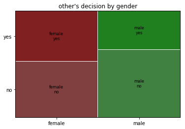

```python
from statsmodels.graphics.mosaicplot import mosaic
df = dating_narrowed[['gender', 'dec_o']]
df = df.replace({'gender': {0:'female', 1:'male'}, 'dec_o':{0:'no', 1:'yes'}})
t = mosaic(df, ['gender', 'dec_o'], title="other's decision by gender")
```

Here we can see that though most people receive a 'no' decision, it is more likely that a female will receive a yes than a male.

## Chi-Square Test

```python
from scipy.stats import chi2_contingency
df = dating_narrowed[['gender', 'dec_o']]
ct = pd.crosstab(df.gender,df.dec_o)
chi2, p, dof, ex = chi2_contingency(ct)
print("chi2 = ", chi2)
print("p-val = ", p)
print("degree of freedom = ",dof)
print("Expected:")
pd.DataFrame(ex)
```

```
chi2 =  103.79970848838241
p-val =  2.238380959241545e-24
degree of freedom =  1
Expected:
```

|  | 0 | 1 |
| --- | --- | --- |
| 0 | 2428.597756 | 1755.402244 |
| 1 | 2434.402244 | 1759.597756 |

Our null hypothesis was that gender did not influence the rate of a positive decision. With a p value as low as ours, it is highly unlikely that our data would look the way it does given a reality where gender doesn't influence a positive decision.

### Q5: Between attractiveness, sincerity, intelligence, fun, and liking, what was the most influential in the final decision (dec)? (5 points)

Hint: Regression would be a good choice here

```python
import statsmodels.formula.api as smf
import statsmodels.api as sm
```

```python
model0 = smf.ols(' dec ~ attr + sinc + intel + fun + like', data=dating_narrowed)
fitted = model0.fit()
fitted.summary()
```

[output not shown]

### Q6: Does the order in which speed daters meet each other matter in terms of final outcome (matches)? (5 points)

Please answer with a statistical test.

Hint: ANOVA might be a good choice

Note: It may be better to create a categorical variable based on whether the pair met "early" or "late" than it is to just use the "order" column

```python
d = {range(1,11): "Early", range(12,22): "Late"}
dating_narrowed['order_def'] = dating_narrowed['order'].apply(lambda x: next((v for k, v in d.items() if x in k), 0))
model1 = smf.ols(' dec ~ order_def', data=dating_narrowed)
fitted = model1.fit()
table = sm.stats.anova_lm(fitted, typ=2) # Type 2 ANOVA DataFrame: no interaction effect
table
```

|  | sum_sq | df | F | PR(>F) |
| --- | --- | --- | --- | --- |
| order_def | 2.036791 | 2.0 | 4.183534 | 0.015276 |
| Residual | 2038.722340 | 8375.0 | NaN | NaN |